# Исследование тарифных планов оператора мобильной связи

#### Ежемесячное изменение суммарной длительности звонков

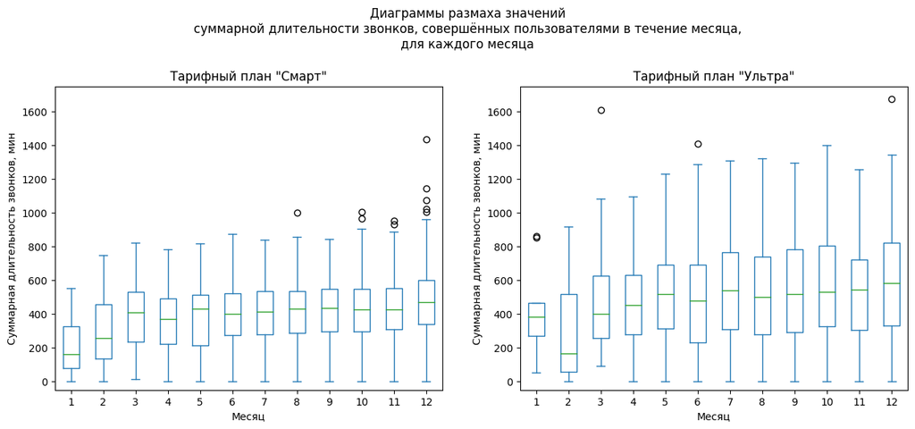

```python
two_graphs('minutes',
           'суммарной длительности звонков, совершённых пользователями в течение месяца,',
           'Суммарная длительность звонков, мин', (-50, 1750))
```

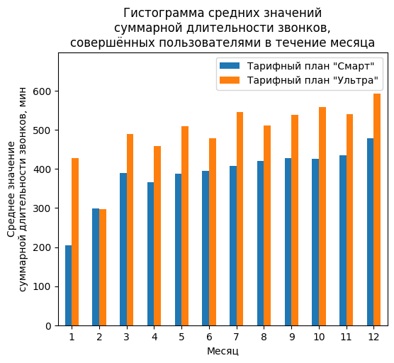

```python
two_hist('minutes',
         'суммарной длительности звонков,\nсовершённых пользователями в течение месяца',
         'суммарной длительности звонков, мин', (0, 699))
```

#### Ежемесячное изменение количества смс-сообщений

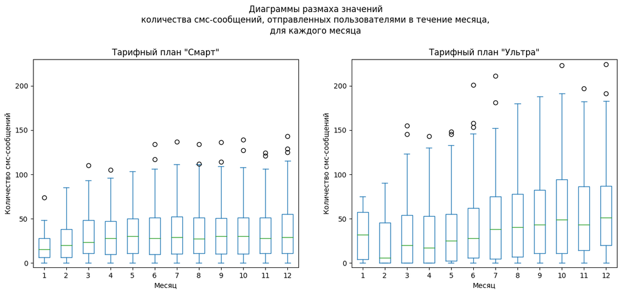

```python
two_graphs('messages',
           'количества смс-сообщений, отправленных пользователями в течение месяца,',
           'Количество смс-сообщений', (-5, 230))
```

#### Ежемесячное изменение количества интернет-сессий

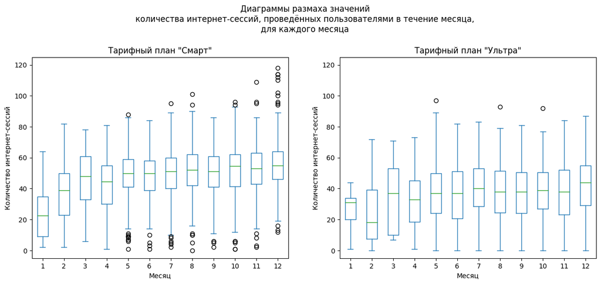

```python
two_graphs('sessions',
           'количества интернет-сессий, проведённых пользователями в течение месяца,',
           'Количество интернет-сессий', (-5, 125))
```

- Ежемесячное количество интернет-сессий, проведённых абонентами тарифного плана "Смарт", растёт с января по март: медианное значение изменяется с 20 до 50 интернет-сессий, проведённых одним пользователем. С марта по декабрь медианное значение остаётся на уровне 50 интернет-сессий с небольшими флуктуациями.
- Межквартильный интервал в период с января по апрель составляет порядка 25 интернет-сессий, а в период с мая по декабрь находится с небольшими отклонениями на уровне 20 интернет-сессий.
- И хотя в течение года наблюдаются случаи, когда абоненты не пользуются интернетом, всё же такие случаи единичны. Минимальное количество интернет-сессий, проведённых одним абонентом, от 1–2 в период с января по апрель растёт до 10—15 в период с мая по декабрь. Максимальное количество интернет-сессий, проведённых одним пользователем, растёт с января по февраль с 65 до 80 интернет-сессий и остаётся приблизительно на уровне 80 интернет-сессий до конца года.
- Ежемесячное количество интернет-сессий, проведённых абонентами тарифного плана "Ультра", резко падает с января по февраль: медианное значение изменяется от 30 до 18 интернет-сессий, проведённых одним пользователем. Затем с февраля по март происходит резкий рост медианного значения с 18 до 35 интернет-сессий и уже до декабря медианное значение остаётся на уровне 35 интернет-сессий, проведённых одним пользователем.
- Межквартильный интервал в период с января по март претерпевает значительные изменения: от 15 интернет-сессий в январе до 40 интернет-сессий в марте. В апреле межквартильный интервал становится на уровне 30 интернет-сессий и с небольшими флуктуациями остаётся таким до конца года.
- В течение года остаются абоненты, которые не пользуются интернетом; только в январе и марте все подключённые к тому моменту абоненты воспользовались хотя бы раз интернетом. Максимальное количество интернет-сессий, проведённых одним пользователем, растёт с 45 в январе до порядка 80 в мае и остаётся на уровне 80 интернет-сессий с небольшими отклонениями до конца года.

#### Ежемесячное изменение объёма интернет-трафика

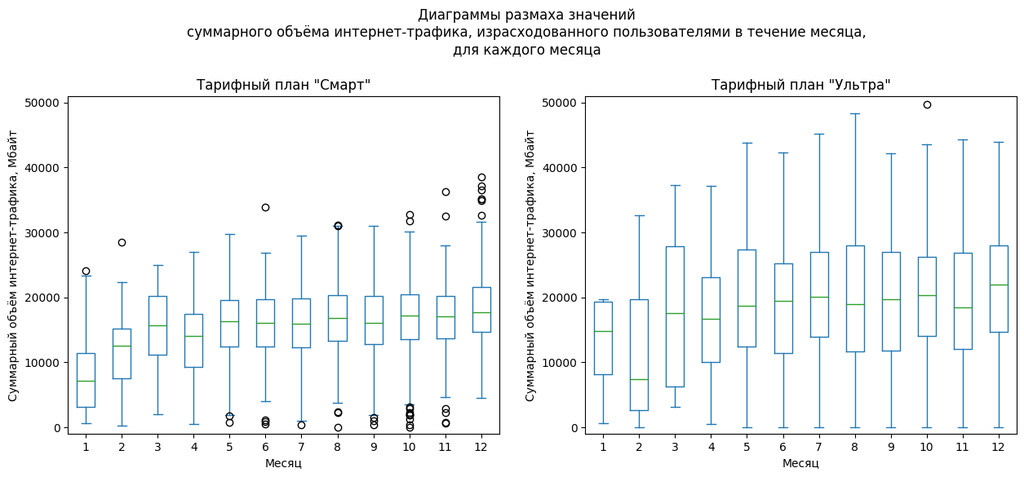

```python
two_graphs('mb_used',
           'суммарного объёма интернет-трафика, израсходованного пользователями в течение месяца,',
           'Суммарный объём интернет-трафика, Мбайт', (-1000, 51000))
```

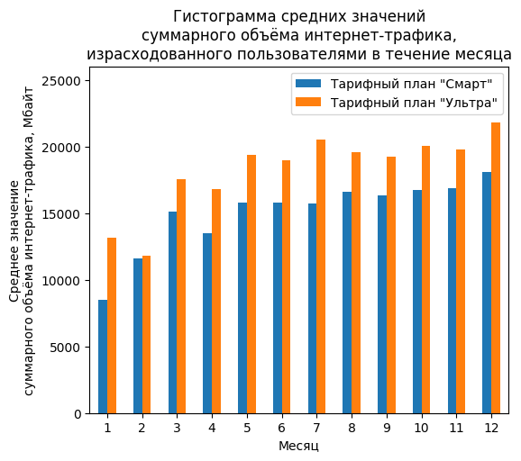

```python
two_hist('mb_used',
         'суммарного объёма интернет-трафика,\nизрасходованного пользователями в течение месяца',
         'суммарного объёма интернет-трафика, Мбайт', (0, 26000))
```

### Проверка гипотез

Для проверки гипотез о равенстве двух выборочных средних будем использовать t-тест. Поскольку значений в выборках много (больше 50), можно использовать t-статистику, так как при таком объёме выборки распределение Стьюдента приближается к нормальному распределению.

#### Сравнение средней ежемесячной выручки, получаемой от абонентов разных тарифных планов

Сформулируем нулевую и альтернативную гипотезы.

$H_0 :$ средняя ежемесячная выручка, получаемая от абонентов тарифных планов "Смарт" и "Ультра", одинаковая.  
$H_1 :$ средняя ежемесячная выручка, получаемая от абонентов тарифных планов "Смарт" и "Ультра", разная.

Проверим нулевую гипотезу о равенстве двух средних при уровне статистической значимости равном 0,05.

```python
alpha = .05

results = st.ttest_ind(
    user_behavior.loc[user_behavior['tariff'] == 'ultra', 'total_cost'],
    user_behavior.loc[user_behavior['tariff'] == 'smart', 'total_cost'],
    equal_var=False
)

print('p-значение:', f'{results.pvalue:.1}')

if results.pvalue < alpha:
    print("Отвергаем нулевую гипотезу")
else:
    print("Не получилось отвергнуть нулевую гипотезу")
```

```
p-значение: 4e-250
Отвергаем нулевую гипотезу
```

**Результат проверки:** нулевая гипотеза о равенстве средних ежемесячных выручек, получаемых от абонентов тарифного плана "Смарт" и от абонентов тарифного плана "Ультра", не может быть принята. Может быть принята альтернативная гипотеза о наличии различий в средних ежемесячных выручках, получаемых от абонентов тарифных планов "Смарт" и "Ультра".

Средние ежемесячные выручки, получаемые от абонентов тарифных планов "Смарт" и "Ультра" различны, различия достоверны при *p* < 0,001.

```python
print(
    'Средняя ежемесячная выручка, получаемая от абонентов тарифного плана "Смарт":',
    user_behavior.loc[user_behavior['tariff'] == 'smart', 'total_cost'].mean().round(), 'руб.',
    '\nСредняя ежемесячная выручка, получаемая от абонентов тарифного плана "Ультра":',
    user_behavior.loc[user_behavior['tariff'] == 'ultra', 'total_cost'].mean().round(), 'руб.'
)
```

```
Средняя ежемесячная выручка, получаемая от абонентов тарифного плана "Смарт": 1290.0 руб.
Средняя ежемесячная выручка, получаемая от абонентов тарифного плана "Ультра": 2070.0 руб.
```

#### Сравнение средней ежемесячной выручки, получаемой от абонентов из Москвы и других городов

Сформулируем нулевую и альтернативную гипотезы.

$H_0 :$ средняя ежемесячная выручка, получаемая от абонентов из города Москвы и из остальных городов, одинаковая.  
$H_1 :$ средняя ежемесячная выручка, получаемая от абонентов из города Москвы и из остальных городов, разная.

Проверим нулевую гипотезу о равенстве двух средних при уровне статистической значимости равном 0,05.

```python
alpha = .05

results = st.ttest_ind(
    user_behavior.loc[user_behavior['city'] == 'Москва', 'total_cost'],
    user_behavior.loc[user_behavior['city'] != 'Москва', 'total_cost'],
    equal_var=False
)

print('p-значение:', results.pvalue.round(3))

if results.pvalue < alpha:
    print("Отвергаем нулевую гипотезу")
else:
    print("Не получилось отвергнуть нулевую гипотезу")
```

```
p-значение: 0.526
Не получилось отвергнуть нулевую гипотезу
```

**Результат проверки:** нулевая гипотеза о равенстве средних ежемесячных выручек, получаемых от абонентов из города Москвы и от абонентов из других городов, может быть принята.

```python
print(
    'Средняя ежемесячная выручка, получаемая от абонентов из города Москвы:',
    user_behavior.loc[user_behavior['city'] == 'Москва', 'total_cost'].mean().round(), 'руб.',
    '\nСредняя ежемесячная выручка, получаемая от абонентов не из города Москвы:',
    user_behavior.loc[user_behavior['city'] != 'Москва', 'total_cost'].mean().round(), 'руб.'
)
```

```
Средняя ежемесячная выручка, получаемая от абонентов из города Москвы: 1547.0 руб.
Средняя ежемесячная выручка, получаемая от абонентов не из города Москвы: 1525.0 руб.
```

## Общий вывод

Для исследовательского анализа данных были использованы сведения о 500 клиентах оператора мобильной связи. Все они являются абонентами либо тарифного плана «Смарт» (351 человек или 70 % всех абонентов), либо тарифного плана «Ультра» (149 человек или 30 % всех абонентов). Для каждого абонента была доступна информация об услугах связи, которыми абонент воспользовался. Для двух человек (один является абонентом тарифного плана «Смарт», другой — абонентом тарифного плана «Ультра») отсутствует информация о количестве использованных услуг и их объёме. Таким образом, исследование поведения пользователей проводилось среди 498 абонентов.

На основе данных о ежедневном использовании абонентами услуг связи был сформирован набор данных, в котором для каждого абонента были рассчитаны потреблённые им в течение месяца объёмы услуг (телефонные звонки, смс-сообщения, интернет-трафик). На основе полученных данных была рассчитана ежемесячная плата, которую клиент вносил за пользование услугами связи. Таким образом, каждое наблюдение в сформированном наборе данных относилось к одной оплате одного абонента. Все такие оплаты, в конечном итоге, и формировали выручку оператора мобильной связи.

Использованные для анализа данные охватывают временной период в один календарный год — с 1 января по 31 декабря 2018 года. Подключения новых абонентов к тарифному плану (или переходы их с другого тарифного плана) происходили в течение года неравномерно. Больше всего новых абонентов было подключено в апреле (53 человека), меньше всего — в марте (32 человека). Наибольшее число новых абонентов тарифного плана «Смарт» наблюдается в июле (37 человек), а тарифного плана «Ультра» — в апреле (18 человек). Наименьшее число новых абонентов подключилось к тарифному плану «Смарт» в марте (19 человек), а к тарифному плану «Ультра» — в июле и декабре (по 7 человек). Однако несмотря на неравномерность изменения количества новых пользователей, всё же половина всех абонентов выполнила подключение в первую половину года, а вторая половина абонентов — во вторую половину года.

Не все абоненты, которые в течение 2018 года подключили тарифный план «Смарт» или «Ультра», продолжили его использовать до конца 2018 года. Отказались от использования нового тарифа 7,6 % всех абонентов (38 человек). Отключения начали производиться с 17 августа. Причём если половина всех отключений произошла за три месяца (до 24 ноября), то вторая половина — за оставшийся месяц.

**Абоненты**

Клиентами оператора мобильной связи являются люди в возрасте от 18 до 75 лет. Их средний возраст составляет 46 лет. Среди клиентов встречаются люди с одинаковой фамилией — однофамильцы или члены одной семьи. Клиенты проживают в 76 различных городах. Больше всего клиентов (99 человек) проживает в Москве. Из Санкт-Петербурга — 39 клиентов, из Новосибирска — 16 человек. Из каждого из остальных городов не более 14 человек.

**Звонки**

Из 498 абонентов только 492 воспользовались услугой телефонной связи для совершения звонков. Количество звонков, совершённых одним пользователем, изменялось от 14 до 1760, что может быть обусловлено, в том числе, разным временем подключения к новому тарифному плану. В среднем абоненты совершили 345 звонков. Длительность звонка могла составлять от 0,01 мин до 38 мин, а в среднем — 8,4 мин.

Всего за рассматриваемый период абонентами было совершено 202 607 звонков. Среди них были как принятые звонки (80 % всех звонков), так и пропущенные (20 % всех звонков). Звонки совершались в течение всего наблюдаемого периода. Больше всего звонков, совершённых абонентами в один день, наблюдалось 31 декабря и составило 1435 звонков.

В течение месяца абонентами совершалось до 244 звонков. В среднем количество звонков одного пользователя в месяц составило 62 звонка. Пользователи тарифного плана «Смарт» совершали до 198 звонков в месяц, в среднем использовали услугу телефонной связи 60 раз. Абоненты тарифного плана «Ультра» в течение месяца выполняли до 244 звонков, в среднем выполняли 74 звонка.

С января по март среднее количество звонков, совершённых одним пользователем тарифного плана «Смарт», растёт с уровня 25 до уровня 60 звонков и остаётся на том же уровне до конца года. Среднее количество звонков, совершённых абонентами тарифного плана «Ультра» в течение месяца, резко снижается в период с января по февраль с уровня 50 до уровня 25 звонков в месяц, затем к маю происходит его рост до уровня 75 звонков в месяц и уже до конца года оно остаётся на том же уровне.

Суммарная длительность всех звонков, совершённых абонентами тарифного плана «Ультра» в течение месяца, могла достигать 1673 мин, а совершённых абонентами тарифного плана «Смарт» — 1435 мин. В среднем суммарная длительность всех звонков, совершённых абонентами тарифного плана «Смарт», составила 418 мин в месяц, а абонентами тарифного плана «Ультра» — 527 мин в месяц.

Поскольку в пакет основных услуг тарифного плана «Ультра» входит 3000 мин разговора, а тарифного плана «Смарт» — 500 мин, то дополнительными минутами разговора воспользовались только абоненты тарифного плана «Смарт». Они могли использовать до 935 дополнительных минут разговора в течение месяца. В среднем количество дополнительных минут, которые использовал один абонент в течение месяца, составило 123 мин.

**Смс-сообщения**

Из 498 абонентов только 426 воспользовались услугой отправки смс-сообщений. Количество смс-сообщений, отправленных одним пользователем, изменялось от 1 до 1463 сообщений. В среднем пользователи отправили 215 смс-сообщений.

Всего за рассматриваемый период абонентами было отправлено 123 036 смс-сообщений. Сообщения отправлялись со 2 января до 31 декабря 2018 года. Больше всего сообщений, отправленных абонентами в течение одного дня, наблюдалось 31 декабря и составило 859 смс-сообщений.

В течение месяца абонентами отправлялось до 224 смс-сообщений. В среднем количество смс-сообщений, отправленных одним пользователем в течение месяца, составило 30 сообщений в месяц. Пользователи тарифного плана «Смарт» отправляли до 143 смс-сообщений в месяц, а в среднем — 28 смс-сообщений в месяц. Абоненты тарифного плана «Ультра» в течение месяца отправляли до 224 смс-сообщений, причём среднее значение отправленных в месяц смс-сообщений составило 38 сообщений.

Поскольку в пакет основных услуг тарифного плана «Ультра» входит 1000 смс-сообщений, а тарифного плана «Смарт» — 50 сообщений, то дополнительными смс-сообщения воспользовались только абоненты тарифного плана «Смарт». Они могли использовать до 93 дополнительных смс-сообщений в течение месяца. В среднем количество дополнительных смс-сообщений, которые использовал один абонент в течение месяца, составило 18 сообщений.

**Интернет-трафик**

Из 498 абонентов почти все используют услугу интернет-связи (497 человек). Количество интернет-сессий, проведённых одним абонентом, изменялось от 8 до 834 интернет-сессий, что, возможно, также в не малой степени обусловлено разным временем подключения абонентов к тарифным планам. В среднем пользователи проводили 284 интернет-сессий. Объём израсходованного интернет-трафика изменялся от 0,03 до 1725 Мбайт за одну интернет-сессию. В среднем пользователи расходовали в течение одной интернет-сессии 426 Мбайт.

Всего за рассматриваемый период абонентами проведено 149 396 интернет-сессий. Интернет-сессии проводились в течение всего наблюдаемого периода. Больше всего интернет-сессий, проведённых абонентами в один день, наблюдалось 31 декабря и 1057 интернет-сессий.

В течение месяца абонентами проводилось до 118 интернет-сессий. В среднем количество интернет-сессий, проведённых одним пользователем в течение месяца, составило 48 интернет-сессий в месяц. Пользователи тарифного плана «Смарт» проводили до 118 интернет-сессий в месяц, в среднем — 51 интернет-сессию. Абоненты тарифного плана «Ультра» в течение месяца проводили до 97 интернет-сессий, причём среднее значение проведённых в месяц интернет-сессий составило 38 интернет-сессий.

С января по март среднее количество интернет-сессий, проведённых одним пользователем тарифного плана «Смарт», растёт с уровня 20 до уровня 50 интернет-сессий в месяц и остаётся на том же уровне с небольшими флуктуациями до конца года. Среднее количество интернет-сессий, проведённых абонентами тарифного плана «Ультра» в течение месяца, резко снижается в период с января по февраль с уровня 30 до уровня 18 интернет-сессий в месяц, затем к марту происходит его рост до уровня 35 интернет-сессий в месяц и уже до конца года оно остаётся на том же уровне.

Суммарный объём интернет-трафика всех интернет-сессий, проведённых абонентами тарифного плана «Ультра» в течение месяца, мог достигать 49 746 Мбайт, а совершённых абонентами тарифного плана «Смарт» — 38 553 Мбайт. В среднем суммарный объём интернет-трафика, израсходованный абонентами тарифного плана «Смарт», составил 16 208 Мбайт в месяц, а абонентами тарифного плана «Ультра» — 19 469 Мбайт в месяц.

В период с января по март средний суммарный объём интернет-трафика, израсходованный абонентами тарифного плана «Смарт» в течение месяца, растёт с уровня 8000 до уровня 15 000 Мбайт в месяц, затем к августу увеличивается до уровня 16 500 Мбайт в месяц. В декабре наблюдается рост до уровня 18 000 Мбайт в месяц. Средний суммарный объём интернет-трафика, израсходованный пользователями тарифного плана «Ультра» в течение месяца, с января по февраль снижается с уровня 13 000 до уровня 11 500 Мбайт в месяц, затем к маю увеличивается до уровня 19 000 Мбайт. Во второй половине года держится на уровне 20 000 Мбайт с небольшими отклонениями.

Поскольку в пакет основных услуг тарифного плана «Ультра» входит 30 Гбайт интернет-трафика, а тарифного плана «Смарт» — 15 Гбайт, то дополнительным объёмом интернет-трафика воспользовались абоненты и тарифного плана «Смарт», и тарифного плана «Ультра». Пользователи тарифного плана «Смарт» могли использовать до 23 Гбайт дополнительного интернет-трафика в течение месяца. В среднем объём интернет-трафика, который использовал один абонент тарифного плана «Смарт» в течение месяца, составил 5,1 Гбайт. Абоненты тарифного плана «Ультра» могли использовать до 19 Гбайт дополнительного трафика в месяц, а в среднем — 5,9 Гбайт в месяц.

**Ежемесячная выручка**

В сформированном наборе данных содержатся сведения о 3214 оплатах, которые клиенты произвели в течение 2018 года. Причём 69 % всех оплат (или 2229 оплат) было произведено абонентами тарифного плана «Смарт», а 31 % всех оплат (или 985 оплат) — абонентами тарифного плана «Ультра». Все такие оплаты формируют выручку компании оператора мобильной связи.

Поскольку абонентская плата за пользование услугами тарифного плана «Смарт» составляет 550 руб. в месяц, а тарифного плана «Ультра» — 1950 руб. в месяц, то каждая оплата, произведённая пользователями, составляла не менее 550 руб. Максимальная произведённая оплата достигала 6770 руб. в месяц. Среднее значение оплаты, произведённой абонентами за пользование услугами мобильной связи, составило 1529 руб. в месяц.

Большинство ежемесячных оплат, произведённых абонентами тарифного плана «Смарт», не превышали размер абонентской платы 550 руб. А поскольку абоненты тарифного плана «Смарт» использовали дополнительные услуги (минуты разговора, смс-сообщения, интернет-трафик), то среднее значение ежемесячной оплаты составило 1290 руб., а максимальная ежемесячная оплата могла достигать 6770 руб.

В результате использования дополнительных минут разговора, ежемесячная плата за пользование тарифным планом «Смарт» могла увеличиваться на 3–2805 руб. в месяц. В среднем за дополнительные минуты разговора абоненты платили 369 руб. в месяц. Таких случаев, когда абоненты тарифного плана «Смарт» использовали дополнительные минуты разговора и вносили за них дополнительную плату сверх размера абонентской платы, было 754 (23 % всех произведённых оплат или 34 % оплат, произведённых абонентами тарифного плана «Смарт»).

Также абоненты тарифного плана «Смарт» использовали дополнительные смс-сообщения. Поэтому ежемесячная оплата за пользование такими сообщениями могла возрасти на 3–279 руб. Среднее значение оплаты, которую абоненты вносили сверх абонентской платы за пользование дополнительными смс-сообщениями, составила 69 руб. в месяц. Таких случаев, когда абоненты тарифного плана использовали дополнительные смс-сообщения и вносили за них дополнительную плату, было 564 (18 % всех произведённых оплат или 25 % оплат, произведённых абонентами тарифного плана «Смарт»).

Но чаще всего абоненты тарифного плана «Смарт» использовали дополнительный объём интернет-трафика. 1304 раз они вносили дополнительную оплату сверх абонентской платы за то, что использовали дополнительный объём интернет-трафика (это почти 59 % оплат, произведённых абонентами тарифного плана «Смарт»). Абоненты дополнительно платили от 200 до 4600 руб. в месяц за пользование интернетом сверх того объёма, который включён в абонентскую плату. Или в среднем — 1022 руб. в месяц.

Большинство ежемесячных оплат, произведённых абонентами тарифного плана «Ультра», не превышали размер абонентской платы 1950 руб. Однако поскольку некоторые абоненты тарифного плана «Ультра» использовали дополнительный объём интернет-трафика, то среднее значение ежемесячной оплаты составило 2070 руб., а максимальная ежемесячная оплата могла достигать 4800 руб.

В результате использования дополнительного объёма интернет-трафика ежемесячная плата за пользование тарифным планом «Ультра» могла увеличиваться на 150–2850 руб. В среднем за дополнительный объём интернет-трафика абоненты платили 883 руб. в месяц. Таких случаев, когда абоненты тарифного плана «Ультра» использовали дополнительный объём интернет-трафика и вносили дополнительную плату сверх размера абонентской платы, было 134 (около 14 % оплат, произведённых абонентами тарифного плана «Ультра»).

Статистическая проверка гипотез показала, что средние ежемесячные выручки, получаемые от абонентов тарифных планов "Смарт" и "Ультра" различны, различия достоверны при *p* < 0,001. Средние значения ежемесячных выручек, оценённые в ходе исследовательского анализа, составили 1290 руб./мес. — от абонентов тарифного плана «Смарт», 2070 руб./мес. — от абонентов тарифного плана «Ультра».

Таким образом, можно заключить, что тарифный план "Ультра" обладает большей прибыльностью для компании оператора мобильной связи по сравнению с тарифным планом "Смарт".